# Predicting “How well we do barbell lifts?” using data from Sports Devices

Sebastián Fuenzalida Garcés  
August 2015

## Load Data

First we need to read the files (included in the repo). After an analysis of the data, to avoid problems with missing data I decided to consider as NA’s: [“NA”, “#DIV/0!”, “”], considering them as moments when the user didn’t do anything or problems with the devices gathering the data.

```r
library(AppliedPredictiveModeling); library(caret); library(rattle); library(randomForest); library(doParallel); library(rpart); library(rpart.plot); library(e1071); library(ROCR); library(mlearning)
registerDoParallel(cores=2)

train_data<-read.csv("pml-training.csv",header=TRUE,na.strings=c("NA","#DIV/0!",""))
test_data<-read.csv("pml-testing.csv",header=TRUE,na.strings=c("NA","#DIV/0!",""))
```

### Relevant Data

Looking at the data we can classify the columns in 3 categories: -Useful Data: Variables that we will use in the model -Not Useful Data: Variables that don’t have any relation with the classe -Data with too many NA’s: variables where more than 80% of the rows are NA’s so we are not going to include them in the model

Considering that we modify the train and test data to have only the useful columns:

```r
#First 7 columns aren't useful for the model (name, time, window, etc...)
train_data<-train_data[,8:length(train_data)]
test_data<-test_data[,8:length(test_data)]

#NearZeroVar gives us a first approach of columns that we don't need
nsv<-nearZeroVar(train_data,saveMetrics=TRUE)

#We exclude the columns that NZV is TRUE (almost all of them are 0 or NA)
train_data<-train_data[,-which(names(train_data) %in% row.names(nsv[nsv$nzv==TRUE,]))]
test_data<-test_data[,-which(names(test_data) %in% row.names(nsv[nsv$nzv==TRUE,]))]

dim(train_data)
```

```
## [1] 19622   118
```

We see that we still have 118 columns, so we are going to do a deeper selection of variables. We are going to find the variables that have some correlation between them using what we learn in Lecture “Preprocessing with PCA”, but using a low correlation (10%) to just find avoid the variables that have a lot of NA’s and weren’t find by the nearZeroVar function.

```r
#We exclude the Classe column
M<-abs(cor(train_data[,-118])); diag(M)<-0
useful_var<-unique(row.names(which(M>0.1,arr.ind=T)))
useful_var<-c(useful_var,"classe")

#Now we subset the train and test data using this columns
vars<-names(train_data) %in% useful_var
train_data<-train_data[vars]
test_data<-test_data[vars]

#Just to be sure we check if both data sets have the same columns
all.equal(names(train_data),names(test_data))
```

```
## [1] "1 string mismatch"
```

We finally get 53 columns that are going to be part of our model, and the only different column is “classe” in train and “problem_id” in test.

## Model Building

We will test 4 different models to compare their “out of sample error” and choose the better one, the models will be:

-Classifitacion Tree with “Cross Validation” and “PreProcessing” -Random Forest with “Cross Validation” -Random Forest with “PreProcessing” -Random Forest with “Cross Validation” and “Preprocessing”

First we need to split the train data in “training” and “testing” to check the accuracy of the models trained.

```r
set.seed(110567)
inTrain<-createDataPartition(y=train_data$classe,p=0.70,list=FALSE)
training<-train_data[inTrain,]
testing<-train_data[-inTrain,]
```

Because of the time it takes to train each model, I decided to SAVE the resulting models in RDS files and load them to make the predictions, but the code used for each of them is ther but not running.

### Model 1: Classification Tree with Cross Validation and PreProcessing

```r
set.seed(110567)
##We train the First Model
modFit_tree <- train(classe ~ .,  preProcess=c("center", "scale"), trControl=trainControl(method = "cv", number = 4,allowParallel=TRUE), data = training, method="rpart")
```

```r
#We load the model
modFit_tree<-readRDS("modFit_tree.RDS")
##We predict the values with the model
predic_tree<-predict(modFit_tree,newdata=testing)
#Now we compare the predictions with the real data
confusionMatrix(predic_tree,testing$classe)
```

```
## Confusion Matrix and Statistics
##
##           Reference
## Prediction    A    B    C    D    E
##          A 1165  254   35  104   56
##          B  214  670   47  155  255
##          C  266  212  940  543  232
##          D    1    3    4  162   17
##          E   28    0    0    0  522
##
## Overall Statistics
##
##                Accuracy : 0.5878
##                  95% CI : (0.5751, 0.6004)
##     No Information Rate : 0.2845
##     P-Value [Acc > NIR] : < 2.2e-16
##
##                   Kappa : 0.4785
##  Mcnemar's Test P-Value : < 2.2e-16
##
## Statistics by Class:
##
##                      Class: A Class: B Class: C Class: D Class: E
## Sensitivity            0.6959   0.5882   0.9162  0.16805  0.48244
## Specificity            0.8934   0.8586   0.7421  0.99492  0.99417
## Pos Pred Value         0.7218   0.4996   0.4286  0.86631  0.94909
## Neg Pred Value         0.8808   0.8968   0.9767  0.85925  0.89503
## Prevalence             0.2845   0.1935   0.1743  0.16381  0.18386
## Detection Rate         0.1980   0.1138   0.1597  0.02753  0.08870
## Detection Prevalence   0.2743   0.2279   0.3726  0.03178  0.09346
## Balanced Accuracy      0.7947   0.7234   0.8292  0.58148  0.73831
```

We can see that the model have a 58.78% of accuracy meaning a 0.4122 out of sample error, not a really good result. In the Appendix we can see the plot of the Tree (Figure 1)

### Model 2: Random Forest with Cross Validation

```r
set.seed(110567)
modFit_Fo_cv<-train(classe ~ ., method="rf", trControl=trainControl(method = "cv", number = 4,allowParallel=TRUE), data=training)
```

```r
modFit_Fo_cv<-readRDS("modFit_Fo_cv.RDS")
predic_Fo_cv<-predict(modFit_Fo_cv,newdata=testing)
confusionMatrix(predic_Fo_cv,testing$classe)
```

```
## Confusion Matrix and Statistics
##
##           Reference
## Prediction    A    B    C    D    E
##          A 1673    6    0    0    0
##          B    1 1131    4    1    1
##          C    0    2 1015   13    0
##          D    0    0    7  950    5
##          E    0    0    0    0 1076
##
## Overall Statistics
##
##                Accuracy : 0.9932
##                  95% CI : (0.9908, 0.9951)
##     No Information Rate : 0.2845
##     P-Value [Acc > NIR] : < 2.2e-16
##
##                   Kappa : 0.9914
##  Mcnemar's Test P-Value : NA
##
## Statistics by Class:
##
##                      Class: A Class: B Class: C Class: D Class: E
## Sensitivity            0.9994   0.9930   0.9893   0.9855   0.9945
## Specificity            0.9986   0.9985   0.9969   0.9976   1.0000
## Pos Pred Value         0.9964   0.9938   0.9854   0.9875   1.0000
## Neg Pred Value         0.9998   0.9983   0.9977   0.9972   0.9988
## Prevalence             0.2845   0.1935   0.1743   0.1638   0.1839
## Detection Rate         0.2843   0.1922   0.1725   0.1614   0.1828
## Detection Prevalence   0.2853   0.1934   0.1750   0.1635   0.1828
## Balanced Accuracy      0.9990   0.9958   0.9931   0.9915   0.9972
```

Using Random Forest with Cross Validation we obtained a much better result with 99.32% accuracy (an interval of [99.08% - 99.51]), meaning a 0.0068 out of sample error.

### Model 3: Random Forest with PreProcessing

```r
set.seed(110567)
modFit_Fo_pp<-train(classe ~ ., method="rf", preProcess=c("center", "scale"), data=training)
```

```r
modFit_Fo_pp<-readRDS("modFit_Fo_pp.RDS")
predic_Fo_pp<-predict(modFit_Fo_pp,newdata=testing)
confusionMatrix(predic_Fo_pp,testing$classe)
```

```
## Confusion Matrix and Statistics
##
##           Reference
## Prediction    A    B    C    D    E
##          A 1672    6    0    0    0
##          B    2 1131    3    2    1
##          C    0    2 1017   12    0
##          D    0    0    6  950    5
##          E    0    0    0    0 1076
##
## Overall Statistics
##
##                Accuracy : 0.9934
##                  95% CI : (0.991, 0.9953)
##     No Information Rate : 0.2845
##     P-Value [Acc > NIR] : < 2.2e-16
##
##                   Kappa : 0.9916
##  Mcnemar's Test P-Value : NA
##
## Statistics by Class:
##
##                      Class: A Class: B Class: C Class: D Class: E
## Sensitivity            0.9988   0.9930   0.9912   0.9855   0.9945
## Specificity            0.9986   0.9983   0.9971   0.9978   1.0000
## Pos Pred Value         0.9964   0.9930   0.9864   0.9886   1.0000
## Neg Pred Value         0.9995   0.9983   0.9981   0.9972   0.9988
## Prevalence             0.2845   0.1935   0.1743   0.1638   0.1839
## Detection Rate         0.2841   0.1922   0.1728   0.1614   0.1828
## Detection Prevalence   0.2851   0.1935   0.1752   0.1633   0.1828
## Balanced Accuracy      0.9987   0.9956   0.9942   0.9916   0.9972
```

In the case of using Rando Forest with PreProcessing but not Cross Validation we obtained 99.34% of accuracy, almost the same of the last one, and a 0.0066 out of sample error.

### Model 4: Random Forest with Cross Validation and PreProcessing

```r
set.seed(110567)
modFit_Fo_cvpp<-train(classe~.,data=training,preProcess=c("center","scale"),trControl=trainControl(method="cv",number=4,allowParallel=TRUE),method="rf")
```

```r
modFit_Fo_cvpp<-readRDS("modFit_Fo_cvpp.RDS")
predic_Fo_cvpp<-predict(modFit_Fo_cvpp,newdata=testing)
confusionMatrix(predic_Fo_cvpp,testing$classe)
```

```
## Confusion Matrix and Statistics
##
##           Reference
## Prediction    A    B    C    D    E
##          A 1673    7    0    0    0
##          B    1 1129    3    1    1
##          C    0    3 1016   13    0
##          D    0    0    7  950    4
##          E    0    0    0    0 1077
##
## Overall Statistics
##
##                Accuracy : 0.9932
##                  95% CI : (0.9908, 0.9951)
##     No Information Rate : 0.2845
##     P-Value [Acc > NIR] : < 2.2e-16
##
##                   Kappa : 0.9914
##  Mcnemar's Test P-Value : NA
##
## Statistics by Class:
##
##                      Class: A Class: B Class: C Class: D Class: E
## Sensitivity            0.9994   0.9912   0.9903   0.9855   0.9954
## Specificity            0.9983   0.9987   0.9967   0.9978   1.0000
## Pos Pred Value         0.9958   0.9947   0.9845   0.9886   1.0000
## Neg Pred Value         0.9998   0.9979   0.9979   0.9972   0.9990
## Prevalence             0.2845   0.1935   0.1743   0.1638   0.1839
## Detection Rate         0.2843   0.1918   0.1726   0.1614   0.1830
## Detection Prevalence   0.2855   0.1929   0.1754   0.1633   0.1830
## Balanced Accuracy      0.9989   0.9950   0.9935   0.9916   0.9977
```

Using both, Cross Validation and PreProcessing gives us a accuracy of 99.32%, same as the one with only Cross Validation.

### Model Comparison

Now we compare the results

-Clasification Tree with CV and PP: 58.78% Accuracy - 0.4122 Sample Error  
-Random Forest with CV: 99.32% Accuracy - 0.0068 Sample Error  
-Random Forest with PP: 99.34% Accuracy - 0.0066 Sample Error  
-Random Forest with CV and PP: 99.32% Accuracy - 0.0068 Sample Error

We can see that clearly the Random Forest gives better results, as expected, and both Preprocessing and Cross Validation gives almost the same results.

In the Figure 2 of the Appendix we can see the plots of the error of the 3 models with Random Forest, showing similar results, and on each of them the comparison between the different classes.

```r
predict(modFit_Fo_cvpp,newdata=test_data)
```

```
##  [1] B A B A A E D B A A B C B A E E A B B B
## Levels: A B C D E
```

## Appendix

### Figure 1

[figure not shown]

### Figure 2

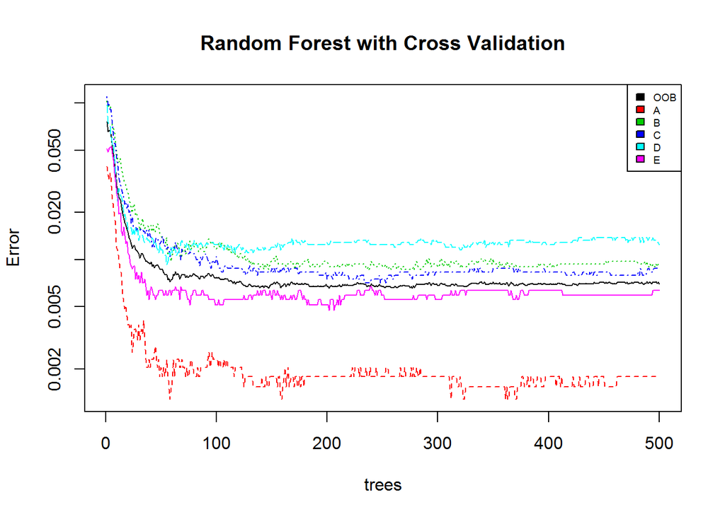

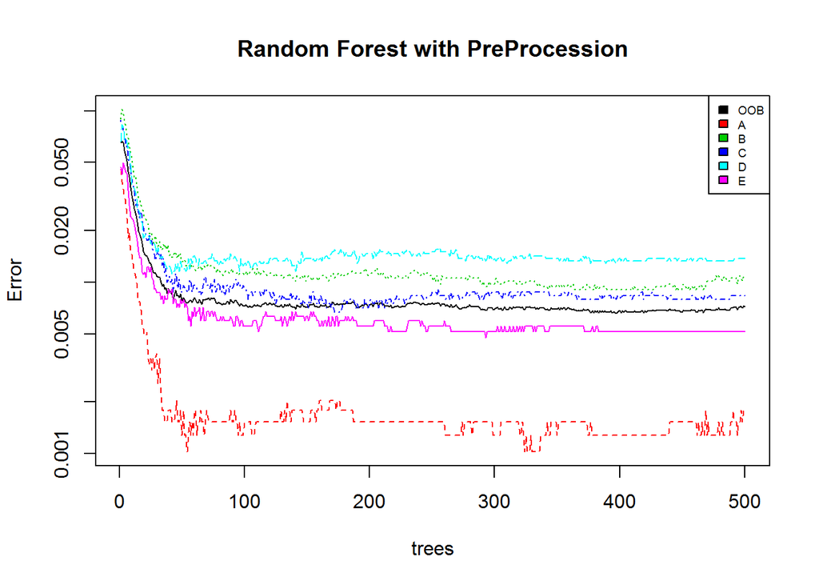

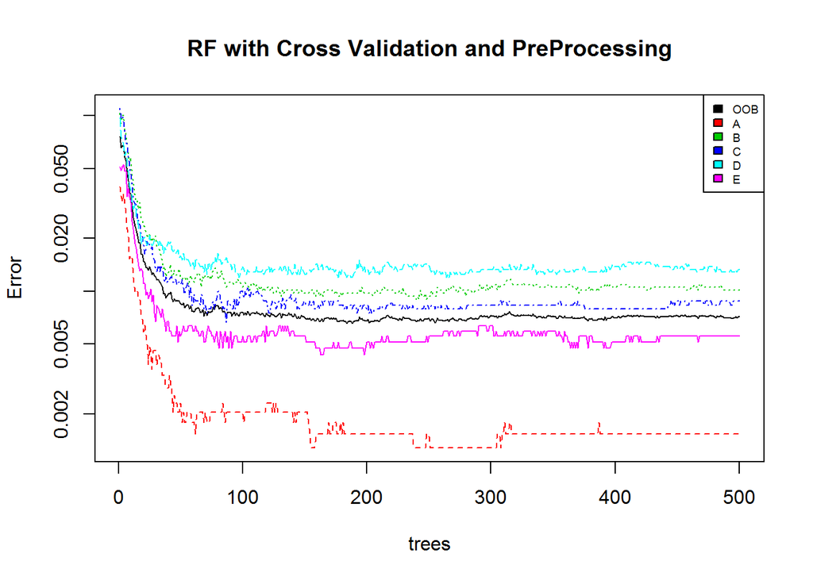